# EDA Executive Summary

Junhua Tan

12/08/2019

## Finding 1: Age and Gender Preference on Travel Destination

Both old and young users have approximately 50% of booking with a slightly higher proportion for young users ~55%, but this difference has not been tested for significance. Both male and female users have approximately the same percentage of booking and not booking (~50%).

1. Users that have not specified their ages and genders seem to have a significantly higher percentage of not booking. This findings can hint to two potential hypotheses: 1) users that have not filled their personal information are less committed to using the site for booking, or 2) users are more likely or required to fill their personal information when deciding to book a place to stay on Airbnb.
2. Users who specific their gender as “OTHER” has a significantly higher percentage of booking (58.3%) than both male and female groups. This can be reasoned for higher stake and effort of the other gender groups to identify differently than the binary genders that again emphasizes the importance of personal information on booking status.
3. Generally, there are a higher proportion of booking in the US as the destination country across gender and age groups. Interestingly, there is a slightly more percentage of male users who booked a place to stay in other non-European countries whereas female users have a slightly higher percentage in booking a place to stay in European countries. In addition, there are also a slightly higher percentage of users identified as other genders to book a place outside of US than other groups.

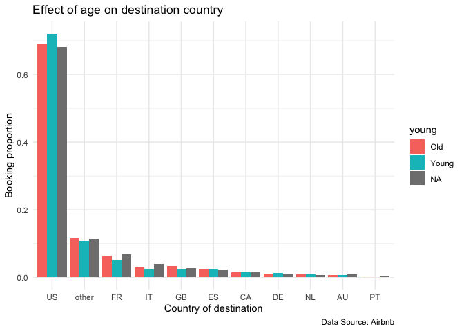

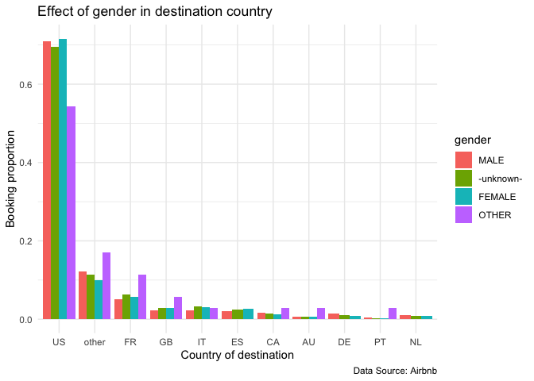

## Finding 2: Accessibility improvement on languages

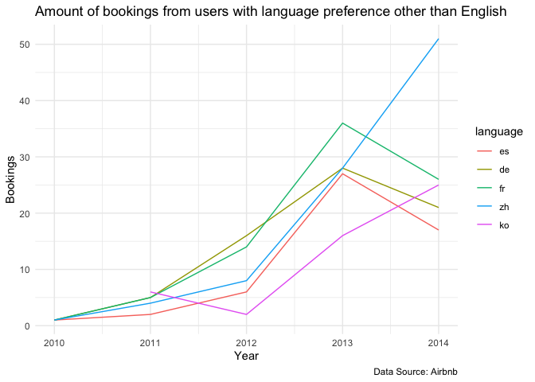